# Lab 4

ECOL 620 - Applications in Landscape Ecology

George Woolsey

15 February, 2023

# Setup

```r
# bread-and-butter
library(tidyverse)
library(lubridate)
library(viridis)
library(scales)
library(latex2exp)
# visualization
library(kableExtra)
# spatial analysis
library(terra)
library(landscapemetrics) #for patch, class, and landscape metrics
library(FedData) #for nlcd color pallette
# set seed
set.seed(11)
```

# Rules

1. Using the provided R Markdown template, answer all questions and show your R code where necessary. Note, some questions are just plain text written answers.
2. Complete your assignment using the R markdown file and submit individual assignments to Canvas. Knit your script and submit an .html file on Canvas. Please use the following naming convention: lab4_firstname_lastname.html (ex. lab4_kyle_horton.html).

# Short Answer

## Question 1

Briefly describe (1-2 sentences) what each of the following functions achieve. All of these functions are seen throughout the Lab #3 example code. (1 pt each).

- `calculate_lsm` is from the `landscapemetrics` package and can be used to calculate several landscape metrics at the user-defined level (i.e. patch, class, or landscape). Landscape metrics include patch area, number of patches, percentage of landscape, and radius of gyration, for example (see `landscapemetrics::list_lsm`).
- `lsm_c_np` is from the `landscapemetrics` package and can be used to calculate the total number of patches (an aggregate metric) at the *class* level.
- `show_cores` is from the `landscapemetrics` package and can be used to create a plot with the core area of patches where the core area is the area of the patch excluding edges of user-defined depth.
- `lsm_l_shei` is from the `landscapemetrics` package and can be used to calculate Shannon’s evenness index (a diversity metric) at the *landscape* level. Shannon’s evenness index is calculated as the ratio between the actual Shannon’s diversity index and and the theoretical maximum of the Shannon diversity index ($SHEI = 0$ when only one patch is present and $SHEI = 1$ when the proportion of classes is completely equally distributed).
- `lsm_l_pd` is from the `landscapemetrics` package and can be used to calculate the patch density (an aggregation metric) at the *landscape* level. Patch density describes the fragmentation the landscape and is calculated as the number of patches ($N$) divided by the total landscape area ($A$ [e.g. in m<sup>2</sup>]).

# Part 1

## Question 2

What is the grain and extent of the Fort Collins raster? (2 pts)

```r
# load data
nlcd <- terra::rast("../data/fort_collins.tif")
# check it
terra::crs(nlcd)
terra::xres(nlcd)
terra::yres(nlcd)
terra::ext(nlcd)
# terra::expanse(nlcd) / 10000 # ha
# x
x_temp <- (terra::ext(nlcd)[2] - terra::ext(nlcd)[1]) / 1000
  # ncol(nlcd) * terra::xres(nlcd) / 1000
# y
y_temp <- (terra::ext(nlcd)[4] - terra::ext(nlcd)[3]) / 1000
  # nrow(nlcd) * terra::yres(nlcd) / 1000
```

The NLCD raster of Fort Collins has a grain size of **30m x 30m** with an extent of **25.6km x 13.3km** and covers an expanse of **34,122.6 ha**.

### NLCD classification functions

```r
# class factor function to return ordered factor from class integer
nlcd_class_fact_fn <- function(class_int){
  return(ordered(class_int
    , levels = FedData::pal_nlcd()$ID
    , labels = FedData::pal_nlcd()$Class
    )
  )
}
# type factor function to return ordered factor from class integer
nlcd_type_fact_fn <- function(class_int){
  return(ordered(class_int
    , levels = c(11,12,21,22,23,24,31,41,42,43,51,52,71,72,73,74,81,82,90,95)
    , labels = c(
      "Water"
      , "Water"
      , "Developed"
      , "Developed"
      , "Developed"
      , "Developed"
      , "Barren"
      , "Forest"
      , "Forest"
      , "Forest"
      , "Shrubland"
      , "Shrubland"
      , "Herbaceous"
      , "Herbaceous"
      , "Herbaceous"
      , "Herbaceous"
      , "Planted/Cultivated"
      , "Planted/Cultivated"
      , "Wetlands"
      , "Wetlands"
      )
    )
  )
}
# FOR LAB type factor function to return ordered factor from class integer
nlcd_labtype_fact_fn <- function(class_int){
  return(ordered(class_int
    , levels = c(41,42,43,21,22,23,24,81,82,71,72,73,74,31,51,52,90,95,11,12)
    , labels = c(
      "Forest"
      , "Forest"
      , "Forest"
      , "Developed"
      , "Developed"
      , "Developed"
      , "Developed"
      , "Agriculture"
      , "Agriculture"
      , "Herbaceous"
      , "Herbaceous"
      , "Herbaceous"
      , "Herbaceous"
      , "Open"
      , "Open"
      , "Open"
      , "Wetlands"
      , "Wetlands"
      , "Water"
      , "Water"
      )
    )
  )
}
# create color pallette based on classes in data
fc_color_pal <- FedData::pal_nlcd() %>%
  dplyr::filter(ID %in% unique(nlcd)[[1]]) %>%
  dplyr::pull(Color)
fc_color_type_pal <-
  FedData::pal_nlcd() %>%
  dplyr::filter(ID %in% unique(nlcd)[[1]]) %>%
  dplyr::mutate(type = nlcd_type_fact_fn(ID)) %>%
  dplyr::group_by(type) %>%
  dplyr::filter(
    n() == 1
    | (n() > 1 & dplyr::row_number() == 2)
  ) %>%
  dplyr::arrange(type) %>%
  dplyr::pull(Color)
fc_color_labtype_pal <-
  FedData::pal_nlcd() %>%
  dplyr::filter(ID %in% unique(nlcd)[[1]]) %>%
  dplyr::mutate(type = nlcd_labtype_fact_fn(ID)) %>%
  dplyr::group_by(type) %>%
  dplyr::filter(
    n() == 1
    | (n() > 1 & dplyr::row_number() == 2)
  ) %>%
  dplyr::arrange(type) %>%
  dplyr::pull(Color)
```

## Question 3

Generate a bar plot showing the proportion of landcover types in the Fort Collins area. Which is most prevalent? Which is least prevalent? Use ggplot for the plotting. (6.5 pts)

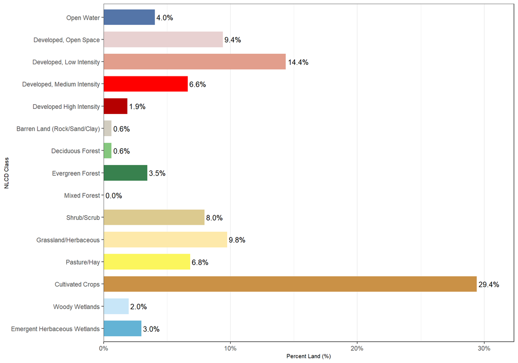

```r
# aggregate percent land by class and apply functions
nlcd_c_pland_temp <- landscapemetrics::lsm_c_pland(nlcd) %>%
  dplyr::mutate(
    nlcd_class = nlcd_class_fact_fn(class)
    , nlcd_type = nlcd_type_fact_fn(class)
  )
# plot
  ggplot(nlcd_c_pland_temp) +
    geom_col(mapping = aes(x = value, y = reorder(nlcd_class, -class), fill = nlcd_class), width = 0.7) +
    scale_fill_manual(values = fc_color_pal) +
    geom_text(
      mapping = aes(
        x = value
        , y = reorder(nlcd_class, -class)
        , label = scales::percent(value, scale = 1, accuracy = .1)
      )
      , color = "black", size = 3.5
      , hjust = -0.1
    ) +
    scale_x_continuous(expand = expansion(mult = c(0, .1)), labels = scales::percent_format(scale = 1)) +
    labs(
        x = "Percent Land (%)"
        , y = "NLCD Class"
    ) +
    theme_bw() +
    theme(
      legend.position = "none"
      , axis.title = element_text(size = 8)
      , axis.text.x = element_text(size = 9)
      , panel.grid.major.y = element_blank()
    )
```

Based on the NLCD raster of Fort Collins, the landcover class that covers the largest area is **Cultivated Crops** which covers **29%** of the raster extent. The landcover class that covers the smallest area is **Mixed Forest** which covers **0.02%** of the raster extent.

## Question 4

Calculate the number of evergreen forest patches in the greater Fort Collins region using: 4-neighborhood rule and the 8-neighborhood rule. (2.5 pts)

```r
get_np_fn <- function(my_dir_rule, my_class_str) {
  return(
    landscapemetrics::lsm_c_np(nlcd, directions = my_dir_rule) %>%
    dplyr::mutate(
      nlcd_class = nlcd_class_fact_fn(class)
      , nlcd_type = nlcd_type_fact_fn(class)
    ) %>%
    dplyr::filter(
      as.character(nlcd_class) %>% toupper() %in% toupper(my_class_str)
    ) %>%
    dplyr::mutate(
      patch_direction_rule = paste0(my_dir_rule,"-neighborhood rule")
    )
  )
}
# create table for answer
c(4,8) %>%
  purrr::map_dfr(get_np_fn, my_class_str = c("evergreen forest")) %>%
  dplyr::select(nlcd_class, patch_direction_rule, value) %>%
  dplyr::arrange(nlcd_class, patch_direction_rule) %>%
  dplyr::mutate(value = value %>% scales::comma(accuracy = 1)) %>%
  kableExtra::kable(
      format = "html"
      , caption = "Number of patches using different patch rules"
      , escape = FALSE
      , col.names = c(
        "NLCD Class"
        , "Patch Rule"
        , "# Patches"
      )
    ) %>%
    kable_styling(font_size = 12)
```

Number of patches using different patch rules

| NLCD Class | Patch Rule | # Patches |
| --- | --- | --- |
| Evergreen Forest | 4-neighborhood rule | 427 |
| Evergreen Forest | 8-neighborhood rule | 174 |

The table above details the number of patches of evergreen forest using a 4-neighborhood rule and a 8-neighborhood rule based on the NLCD raster of Fort Collins.

## Question 5

What is the mean pasture/hay patch size in hectare and km2 (using the 4-neighborhood rule): (2.5 pts)

```r
# native units is ha
areamn_temp <- landscapemetrics::lsm_c_area_mn(nlcd, directions = 4) %>%
  dplyr::mutate(
    nlcd_class = nlcd_class_fact_fn(class)
    , nlcd_type = nlcd_type_fact_fn(class)
  ) %>%
  dplyr::filter(
    as.character(nlcd_class) %>% toupper() %in% toupper("pasture/hay")
  ) %>%
  dplyr::pull(value)
```

The mean patch size of pasture/hay patches in the NLCD raster of Fort Collins is **2.1** ha (**0.021** km<sup>2</sup>).

## Question 6

Of the open water patch-based metrics (using the 4-neighborhood rule), which have the strongest negative correlations? Include the top-three pairings. (3 pts)

```r
# get landscape metrics in data frame
water_lsm_temp <- landscapemetrics::calculate_lsm(nlcd, level = "patch", directions = 4, full_name = TRUE) %>%
  dplyr::mutate(
    nlcd_class = nlcd_class_fact_fn(class)
    , nlcd_type = nlcd_type_fact_fn(class)
  ) %>%
  dplyr::filter(
    as.character(nlcd_class) %>% toupper() %in% toupper("open water")
  ) %>%
  dplyr::select(id, function_name, value, nlcd_class) %>%
  # pivot wider
  tidyr::pivot_wider(
    names_from = function_name
    , values_from = value
  )
# calculate correlation matrix
  cor_matrix <- water_lsm_temp %>%
    dplyr::select(-c(id, nlcd_class)) %>%
    cor()
  # keep lower triangle
  cor_matrix[!lower.tri(cor_matrix, diag = FALSE)] <- NA
  cor_matrix <- cor_matrix[2:nrow(cor_matrix), 1:ncol(cor_matrix)-1]
  # create data frame of correlation matrix
  cor_matrix_df <- cor_matrix %>%
    as.data.frame() %>%
    tibble::rownames_to_column(var = "var1") %>%
    tidyr::pivot_longer(
      cols = c(-var1)
      , names_to = "var2"
    ) %>%
    dplyr::filter(!is.na(value)) %>%
    dplyr::arrange(value) %>%
    # attach patch metric variable descriptions
    dplyr::left_join(
      landscapemetrics::list_lsm() %>% dplyr::select(name, function_name) %>% rename(name1 = name)
      , by = c("var1" = "function_name")
    ) %>%
    dplyr::left_join(
      landscapemetrics::list_lsm() %>% dplyr::select(name, function_name) %>% rename(name2 = name)
      , by = c("var2" = "function_name")
    )
  # create table for answer
  cor_matrix_df %>%
    dplyr::slice_min(order_by = value, n = 3) %>%
    dplyr::select(name1, name2, value) %>%
    kableExtra::kable(
      format = "html"
      , caption = "Top 3 negative correlations in patch-based metrics<br>NLCD class: open water"
      , escape = FALSE
      , digits = 2
      , col.names = c(
        "Metric 1"
        , "Metric 2"
        , "Pearson Corr. Coeff."
      )
    ) %>%
    kable_styling(font_size = 12)
```

Top 3 negative correlations in patch-based metrics NLCD class: open water

| Metric 1 | Metric 2 | Pearson Corr. Coeff. |
| --- | --- | --- |
| perimeter-area ratio | contiguity index | -0.99 |
| perimeter-area ratio | core area index | -0.79 |
| perimeter-area ratio | fractal dimension index | -0.73 |

The table above includes the top three open water patch-based metrics (using a 4-neighborhood rule) which have the strongest negative correlation.

## Question 7

Generate a plot showing the relationship between the number of open water patches (using the 4-neighborhood rule) and grain size. Use 30m, 60m, 120m, 240, and 600m grain resolution. Use the modal rule and generate your plot using ggplot. (10 pts)

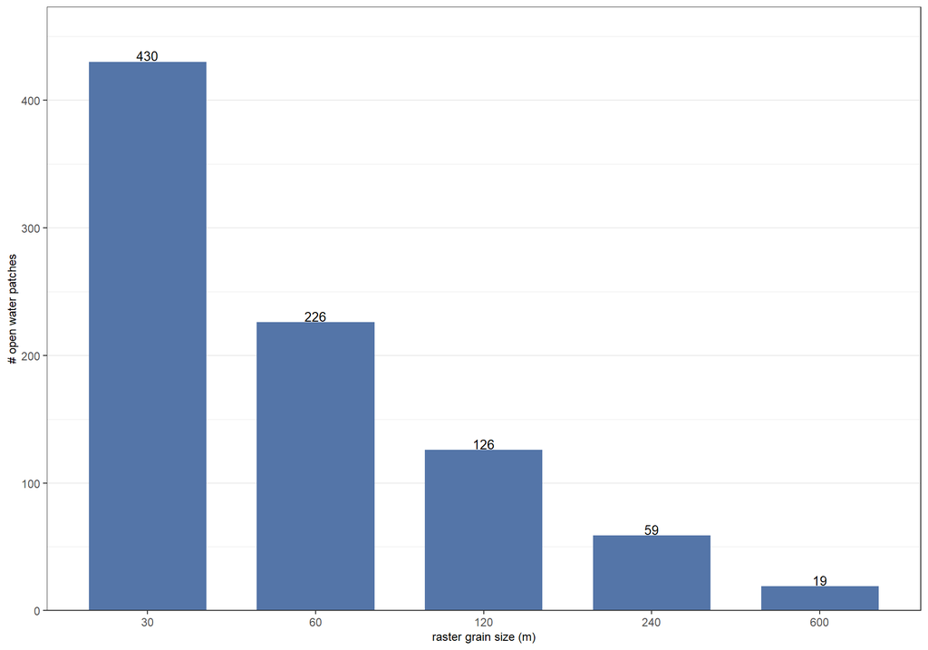

```r
# define function to return data on patches by class, grain, direction
fn_agg_rst <- function(my_res, my_data, my_dir_rule) {
  return(
  if(my_res>terra::xres(my_data)[1]){
    # aggregate raster
      terra::aggregate(my_data
        , fact = (my_res/terra::xres(my_data)[1])
        , fun = "modal"
      ) %>%
    # calculate number of patches
      landscapemetrics::lsm_c_np(directions = my_dir_rule) %>%
    # add identifying vars
      dplyr::mutate(
        rast_resolution = my_res
        , patch_direction_rule = my_dir_rule
      )
  }else{if(my_res==terra::xres(my_data)[1]){ # no need to agg. if at native res
      my_data %>%
    # calculate number of patches
      landscapemetrics::lsm_c_np(directions = my_dir_rule) %>%
    # add identifying vars
      dplyr::mutate(
        rast_resolution = my_res
        , patch_direction_rule = my_dir_rule
      )
  }}
  )
}
# create data frame of spatial variance vs grain using function defined above
df_grain_patch <- c(30, 60, 120, 240, 600)  %>% # define sequence for factors
  # map = apply a function to each element of a list
  purrr::map_dfr(fn_agg_rst, my_data = nlcd, my_dir_rule = 4) %>%
  # create class factors
  dplyr::mutate(
    nlcd_class = nlcd_class_fact_fn(class)
    , nlcd_type = nlcd_type_fact_fn(class)
  )
# plot
df_grain_patch %>%
  dplyr::filter(
    nlcd_class %>% toupper() == toupper("open water")
  ) %>%
ggplot(.) +
  geom_col(
    mapping = aes(x = as.factor(rast_resolution), y = value)
    , width = 0.7
    , fill = FedData::pal_nlcd() %>%
        dplyr::filter(Class %>% toupper() %in% toupper("open water")) %>%
        dplyr::pull(Color)
  ) +
  geom_text(
    mapping = aes(x = as.factor(rast_resolution), y = value, label = value)
    , color = "black", size = 3.5
    , vjust = -0.1
  ) +
  scale_y_continuous(expand = expansion(mult = c(0, .1))) +
  labs(
    y = "# open water patches"
    , x = "raster grain size (m)"
  ) +
  theme_bw() +
  theme(
    legend.position = "none"
    , axis.title = element_text(size = 9)
    , panel.grid.major.x = element_blank()
  )
```

# Part 2

For questions 8-10, reclassify “fort_collins.tif” to the scheme outlined on lines 44 to 51. Calculate the following metrics:

## Question 8

Number of agriculture patches in the greater Fort Collins region using: 4-neighborhood rule & 8-neighborhood rule: (4.5 pts)

```r
# get nlcd classes
nlcd_classes <- levels(as.factor(nlcd))[[1]]
# get nlcd types based on classes
nlcd_types <- nlcd_labtype_fact_fn(nlcd_classes %>% as.integer())
#create reclassify matrix: first col: original; second: change to
nlcd_reclass_matrix <- cbind(nlcd_classes, nlcd_types)
#reclassify with classify function
nlcd_rast_type <- terra::classify(as.factor(nlcd), nlcd_reclass_matrix)
# aggregate patches
get_np_fn <- function(my_dir_rule, my_type_str) {
  return(
    nlcd_rast_type %>%
    landscapemetrics::lsm_c_np(directions = my_dir_rule) %>%
    dplyr::mutate(
      nlcd_type = ordered(
        class
        , levels = c(1:length(nlcd_types %>% unique))
        , labels = nlcd_types %>% unique %>% sort
      )
    ) %>%
    dplyr::filter(
      as.character(nlcd_type) %>% toupper() %in% toupper(my_type_str)
    ) %>%
    dplyr::mutate(
      patch_direction_rule = paste0(my_dir_rule,"-neighborhood rule")
    )
  )
}
# create table for answer
c(4,8) %>%
  purrr::map_dfr(get_np_fn, my_type_str = c("agriculture")) %>%
  dplyr::select(nlcd_type, patch_direction_rule, value) %>%
  dplyr::arrange(nlcd_type, patch_direction_rule) %>%
  dplyr::mutate(value = value %>% scales::comma(accuracy = 1)) %>%
  kableExtra::kable(
      format = "html"
      , caption = "Number of patches using different patch rules"
      , escape = FALSE
      , col.names = c(
        "Landcover Type"
        , "Patch Rule"
        , "# Patches"
      )
    ) %>%
    kable_styling(font_size = 12)
```

Number of patches using different patch rules

| Landcover Type | Patch Rule | # Patches |
| --- | --- | --- |
| Agriculture | 4-neighborhood rule | 1,213 |
| Agriculture | 8-neighborhood rule | 120 |

The table above details the number of agricultural patches using a 4-neighborhood rule and a 8-neighborhood rule based on the NLCD raster of Fort Collins and a grouping of the NLCD classes into landcover type.

## Question 9

Calculate the mean Euclidean nearest neighbor distance of agriculture patches (Using the 4-neighborhood rule): (3 pts)

```r
# Calculate the mean Euclidean nearest neighbor distance
nlcd_rast_type %>% landscapemetrics::lsm_p_enn(directions = 4) %>%
  dplyr::mutate(nlcd_type = ordered(
        class
        , levels = c(1:length(nlcd_types %>% unique))
        , labels = nlcd_types %>% unique %>% sort
      )
      , patch_direction_rule = paste0(4,"-neighborhood rule")
  ) %>%
  dplyr::group_by(
    nlcd_type, patch_direction_rule
  ) %>%
  dplyr::summarise(
    mean_value = mean(value, na.rm = TRUE)
  ) %>%
  dplyr::filter(
      as.character(nlcd_type) %>% toupper() %in% toupper("Agriculture")
  ) %>%
  kableExtra::kable(
    format = "html"
    , caption = "Distance to the nearest neighboring patch of the same class<br>Euclidean Nearest-Neighbor Distance"
    , escape = FALSE
    , digits = 2
    , col.names = c(
      "Landcover Type"
      , "Patch Rule"
      , "Mean Nearest-Neighbor Distance (m)"
    )
  ) %>%
  kable_styling(font_size = 12)
```

Distance to the nearest neighboring patch of the same class Euclidean Nearest-Neighbor Distance

| Landcover Type | Patch Rule | Mean Nearest-Neighbor Distance (m) |
| --- | --- | --- |
| Agriculture | 4-neighborhood rule | 43.85 |

The table above details the mean distance to the nearest neighboring patch of the same class (i.e. Euclidean Nearest-Neighbor Distance) for agricultural patches using a 4-neighborhood rule based on the NLCD raster of Fort Collins and a grouping of the NLCD classes into landcover type.

## Question 10

Include a plot (using the landscape metrics package, e.g., show_lsm) of developed and open water landcover types showing the area in hectares (Using the 4-neighborhood rule). (2 pts)

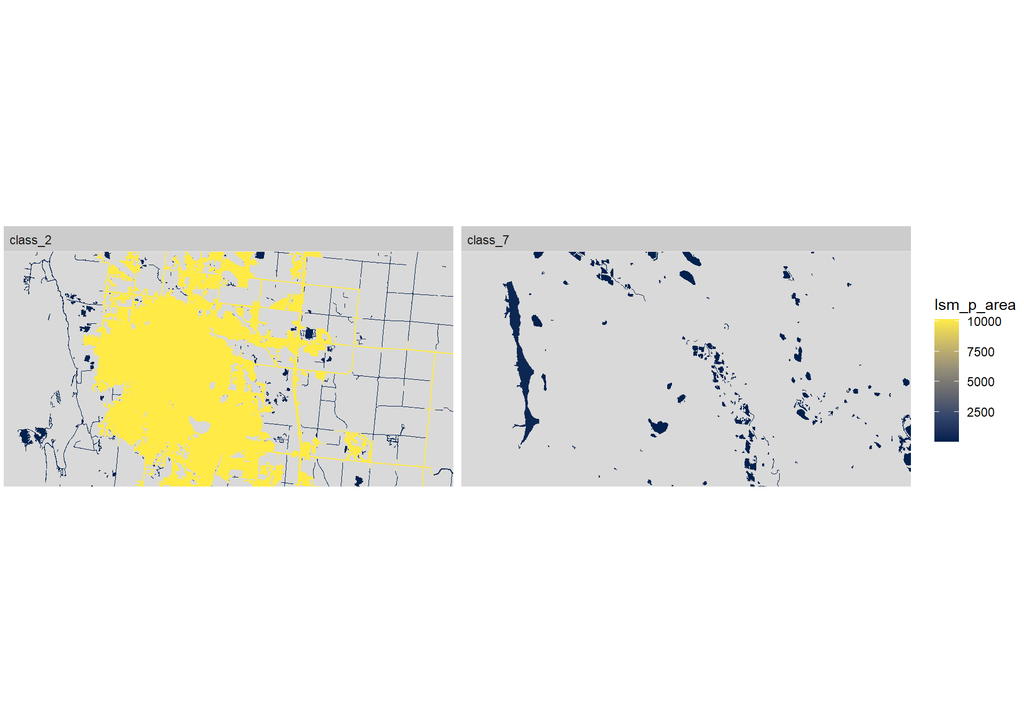

```r
filter_nlcd_types <- (nlcd_types %>% unique %>% sort)[
  (nlcd_types %>% unique %>% sort)
    %in% c("Developed", "Water")] %>%
  as.numeric()
# plot
landscapemetrics::show_lsm(
  nlcd_rast_type
  , what = "lsm_p_area"
  , direction = 4
  , class = filter_nlcd_types
  , label_lsm = FALSE
  , labels = FALSE
)
```

The figure above shows all patches of land classified as developed (class 2) and water (class 7) with a fill corresponding to the value of patch area (ha). This plot was produced using `landscapemetrics::show_lsm` with the patch-level metric parameter set to `lsm_p_area`.

# Part 3

Calculate the following landscape metrics (for the original fort_collins.tif, i.e., before reclassification). In addition to quantifying the values, briefly describe the meaning of the values. For instance, what does a “high” value of shannon evenness indicate?

## Question 11

Land-cover richness: (2 pts)

```r
# landscape level
richness_temp <- nlcd %>% landscapemetrics::lsm_l_pr() %>% dplyr::pull(value)
 # == nlcd %>% values() %>% unique() %>% length()
```

The NLCD raster of Fort Collins has a land cover richness of **15**. Land cover richness is simply a count of the number of classes (land cover types) in a given area. It is not comparable across landscapes with different total area.

## Question 12

Shannon diversity:(3.5 pts)

```r
# landscape level
shdi_temp <- nlcd %>% landscapemetrics::lsm_l_shdi() %>% dplyr::pull(value) %>% round(2)
```

The NLCD raster of Fort Collins has a Shannon’s diversity index (SHDI) of **2.22**. Shannon’s diversity index is a meaure of the proportionality of landcover types in a given area. Shannon’s diversity index increases as the richness and the evenness of land cover increases (SHDI = 0 when only one patch is present). The theoretical maximum of the SHDI = $\ln(m)$ where $m$ is the number of classes.

SHDI is represented by:

$$SHDI = -1 \times \sum_{i = 1}^{m} \bigl(p_{i} \times \ln(p_{i}) \bigr)$$

where $m$ is the number of classes and $p_i$ is the proportion of class $i$.

## Question 13

Shannon evenness: (3.5 pts)

```r
# landscape level
shei_temp <- nlcd %>% landscapemetrics::lsm_l_shei() %>% dplyr::pull(value) %>% round(2)
```

The NLCD raster of Fort Collins has a Shannon’s evenness index (SHEI) of **0.82**. Shannon’s evenness index is a meaure of the dominance of landcover in a given area. It is the ratio between Shannon’s diversity index (SHDI) and and the theoretical maximum of SHDI. As such, Shannon’s evenness index is constrained between 0 and 1. As the eveness of patch distribution increases, SHEI approaches 1 (SHEI = 1 under complete equal distribution of patches; SHEI = 0 when only one patch is present). SHEI is represented by:

$$SHEI = \frac{SHDI}{\ln(m)} = \frac{-1 \times \sum_{i = 1}^{m}
\bigl(p_{i} \times \ln(p_{i}) \bigr)} {\ln(m)}$$

where $m$ is the number of classes and $p_i$ is the proportion of class $i$.